# Examen Módulo 3

# Examen Módulo 3: Análisis de Datos Multivariantes I

Año 2020

## Instrucciones

- Deben realizar los ejercicios en RMarkdown, en el que además del código R con todos los procesos que hayan realizado para ejecutar los ejercicios, deben incluir los comentarios y explicaciones del resultado de los mismos, cuestión que como se les ha ido indicando durante todo el trimestre, es lo más importante, que sepan interpretar los resultados.
- La resolución de sus casos deberán entregarla a través de la aplicación del curso virtual en el enlace del menú izquierdo “TAREAS” (conforme a las instrucciones dadas en el foro). Tengan en cuenta que deben subir a la aplicación el fichero html que generen, NO el fichero de R.
- La fecha máxima de entrega del trabajo es el 22 de marzo. Pueden subirlo antes si lo tienen terminado.

## Ejercicio 1

Lea los datos del fichero oecd, el cual tiene los siguientes campos:

- country
- GDP (PIB)
- debt.gdp.ratio (Ratio de deuda sobre el PIB)
- debt (deuda)
- share.of.debt (porcentaje de deuda sobre el total de la deuda de la OCDE)

Muestre los primeros y los últimos registros y realice un sumario de estadísticas.

Represente gráficamente la relación entre la ratio de deuda sobre el PIB (X) y el porcentaje de deuda sobre el total de la deuda de la OCDE (Y). Ponga título al gráfico y a los ejes X e Y.

### Lectura de datos

```r
oecd <- read.csv('../Data/oecd.txt', sep = ',', header = T)
str(oecd)
```

```
## 'data.frame':    36 obs. of  5 variables:
##  $ country       : Factor w/ 36 levels "Australia","Austria",..: 36 18 17 10 11 35 4 31 30 1 ...
##  $ gdp           : num  19485 4872 1944 2582 3693 ...
##  $ debt.gdp.ratio: num  82.3 223.8 131.2 98.5 64.1 ...
##  $ debt          : num  16036 10904 2550 2544 2367 ...
##  $ share.of.debt : num  35.25 23.97 5.61 5.59 5.2 ...
```

### Visualización de datos y estadísticas

```r
head(oecd)
```

```
##          country   gdp debt.gdp.ratio  debt share.of.debt
## 1  United States 19485           82.3 16036         35.25
## 2          Japan  4872          223.8 10904         23.97
## 3          Italy  1944          131.2  2550          5.61
## 4         France  2582           98.5  2544          5.59
## 5        Germany  3693           64.1  2367          5.20
## 6 United Kingdom  2631           87.0  2289          5.03
```

```r
tail(oecd)
```

```
##       country  gdp debt.gdp.ratio  debt share.of.debt
## 31   Slovenia 48.5           78.6 38.09          0.08
## 32  Lithuania 47.5           38.9 18.49          0.04
## 33    Iceland 24.5           47.4 11.60          0.03
## 34     Latvia 30.5           38.9 11.85          0.03
## 35 Luxembourg 62.3           19.3 12.03          0.03
## 36    Estonia 25.9            9.3  2.41          0.01
```

```r
summary(oecd)
```

```
##            country        gdp        debt.gdp.ratio       debt
##  Australia     : 1   Min.   :   24   Min.   :  9.3   Min.   :    2
##  Austria       : 1   1st Qu.:  200   1st Qu.: 38.4   1st Qu.:   74
##  Belgium       : 1   Median :  408   Median : 51.5   Median :  237
##  Canada        : 1   Mean   : 1386   Mean   : 67.2   Mean   : 1264
##  Chile         : 1   3rd Qu.: 1338   3rd Qu.: 83.5   3rd Qu.:  668
##  Czech Republic: 1   Max.   :19485   Max.   :223.8   Max.   :16036
##  (Other)       :30
##  share.of.debt
##  Min.   : 0.0
##  1st Qu.: 0.2
##  Median : 0.5
##  Mean   : 2.8
##  3rd Qu.: 1.5
##  Max.   :35.2
##
```

### Obtención de gráficos

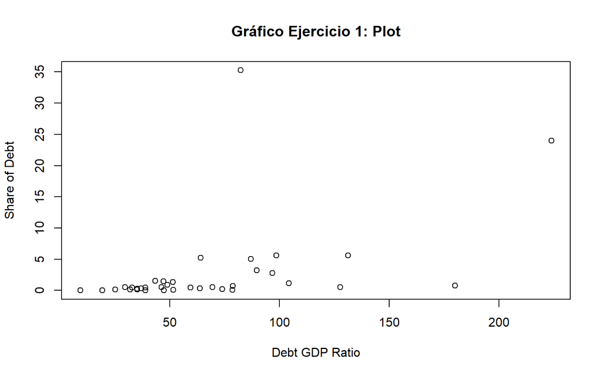

```r
# Gráfica con plot

plot(oecd$debt.gdp.ratio,
     oecd$share.of.debt,
     main='Gráfico Ejercicio 1: Plot',
     xlab='Debt GDP Ratio',
     ylab='Share of Debt')
```

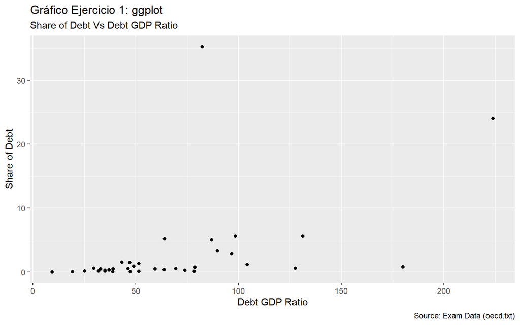

```r
# Gráfica con ggplot2

library(ggplot2)

gg <- ggplot(oecd,
            aes(x=debt.gdp.ratio, y=share.of.debt)) +
            geom_point() +
            labs(title="Gráfico Ejercicio 1: ggplot",
                 subtitle="Share of Debt Vs Debt GDP Ratio",
                 y="Share of Debt",
                 x="Debt GDP Ratio",
                 caption = "Source: Exam Data (oecd.txt)")
plot(gg)
```

## Ejercicio 2

Realice una regresión lineal simple por Mínimos Cuadrados Ordinarios.

Presente sumario de resultados y estadísticas de los residuos.

Responda:

- ¿Son significativos los coeficientes?
- ¿Son normales los residuos?
- ¿Hay problemas de valores extremos?
- ¿Hay problemas de heterocedasticidad?
- ¿La transformación logarítmica de los datos resuelve los problemas que ha encontrado?

### Ejecución de modelos y primeras conclusiones

```r
regresion_mco <- lm(share.of.debt ~ debt.gdp.ratio, data = oecd)
summary(regresion_mco)
```

```
##
## Call:
## lm(formula = share.of.debt ~ debt.gdp.ratio, data = oecd)
##
## Residuals:
##     Min      1Q  Median      3Q     Max
## -10.206  -1.914  -0.444   0.440  31.368
##
## Coefficients:
##                Estimate Std. Error t value Pr(>|t|)
## (Intercept)     -2.1203     1.8999   -1.12   0.2723
## debt.gdp.ratio   0.0729     0.0237    3.08   0.0041 **
## ---
## Signif. codes:  0 '***' 0.001 '**' 0.01 '*' 0.05 '.' 0.1 ' ' 1
##
## Residual standard error: 6.22 on 34 degrees of freedom
## Multiple R-squared:  0.218,  Adjusted R-squared:  0.195
## F-statistic: 9.47 on 1 and 34 DF,  p-value: 0.00411
```

- Como se puede observar, **el único coeficiente significativo sería “Debt GDP Ratio” si tomamos una significación estándar del 95%**. En cambio, el intercept no es significativo a ningún nivel de confianza.
- **El R^2 múltiple es de 0,21, lo que indica una correlación muy pobre.** El ajustado, al no tener clases desbalanceadas ni otros fenómenos, resulta también pobre en la misma línea.
- El **p-value es 0.004 < 0.05**, lo que nos indica que el modelo es significativo.

De esta manera, parece ser que este modelo es muy malo y que necesita alguna transformación. Probemos con la logarítmica:

```r
regresion_mco_log <- lm( log(share.of.debt) ~ log(debt.gdp.ratio), data = oecd )
summary(regresion_mco_log)
```

```
##
## Call:
## lm(formula = log(share.of.debt) ~ log(debt.gdp.ratio), data = oecd)
##
## Residuals:
##    Min     1Q Median     3Q    Max
## -2.613 -0.700  0.258  0.948  3.381
##
## Coefficients:
##                     Estimate Std. Error t value Pr(>|t|)
## (Intercept)            -8.91       1.50   -5.92  1.1e-06 ***
## log(debt.gdp.ratio)     2.06       0.37    5.58  3.1e-06 ***
## ---
## Signif. codes:  0 '***' 0.001 '**' 0.01 '*' 0.05 '.' 0.1 ' ' 1
##
## Residual standard error: 1.38 on 34 degrees of freedom
## Multiple R-squared:  0.478,  Adjusted R-squared:  0.462
## F-statistic: 31.1 on 1 and 34 DF,  p-value: 3.05e-06
```

- Como podemos observar en este caso, también cogiendo un **nivel de significación del 95%, los dos (Intercept y log(debt gdp ratio)) son significativos**, de tal manera que las dos variables aportan información al modelo.
- Como contrapartida, **el R^2 obtenido sigue siendo bastante malo, con 0,478 como valor**, aunque mejora mucho el R^2 obtenido en el modelo anterior. El R^2 ajustado sigue la línea del múltiple, con valor bajo de ajuste para el modelo.
- Esta mejora viene de la logaritmización de las variables, puesto que los valores extremos que se muestran en la gráfica del ejercicio 1 se “suavizan” con los logaritmos.

### Interpretaciones de las gráficas de los modelos

**Modelo Original**

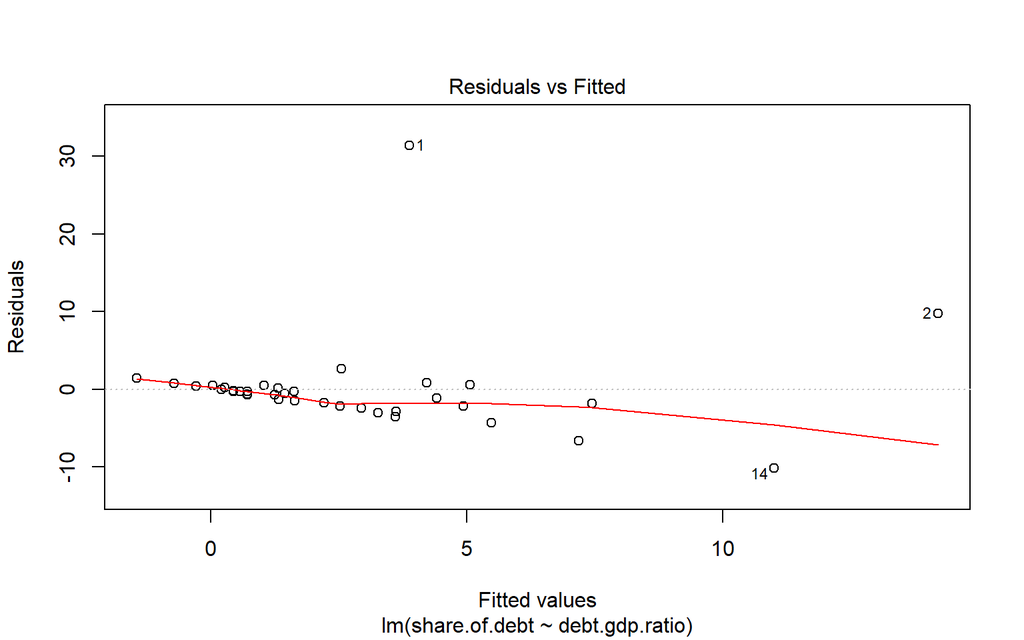

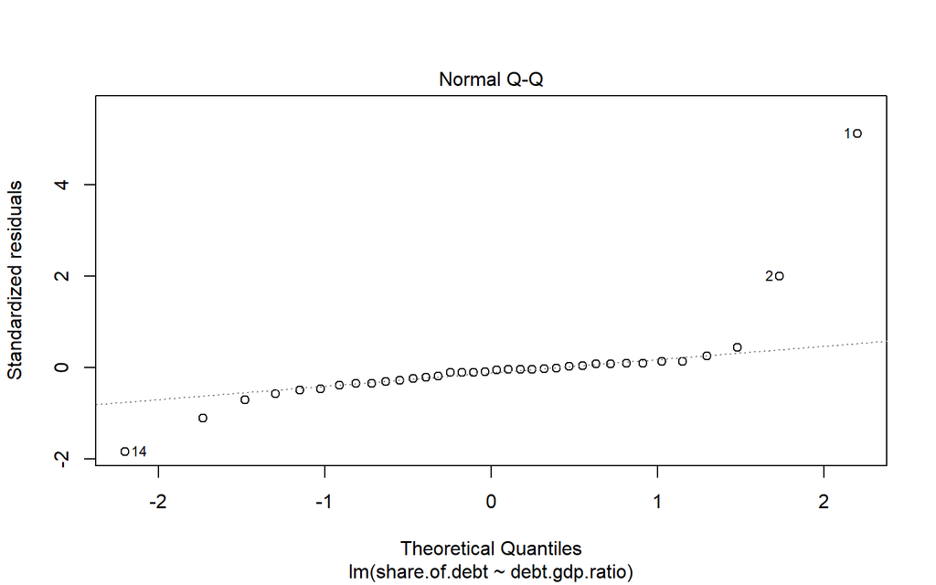

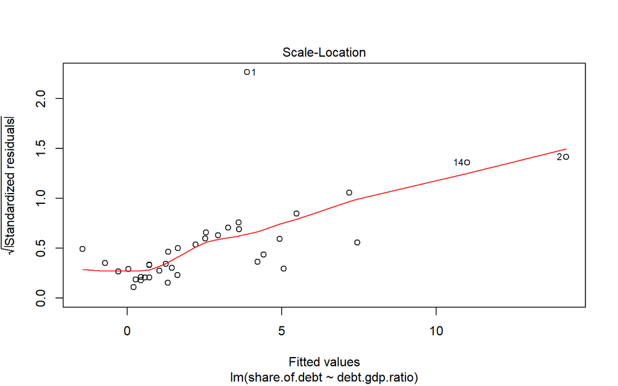

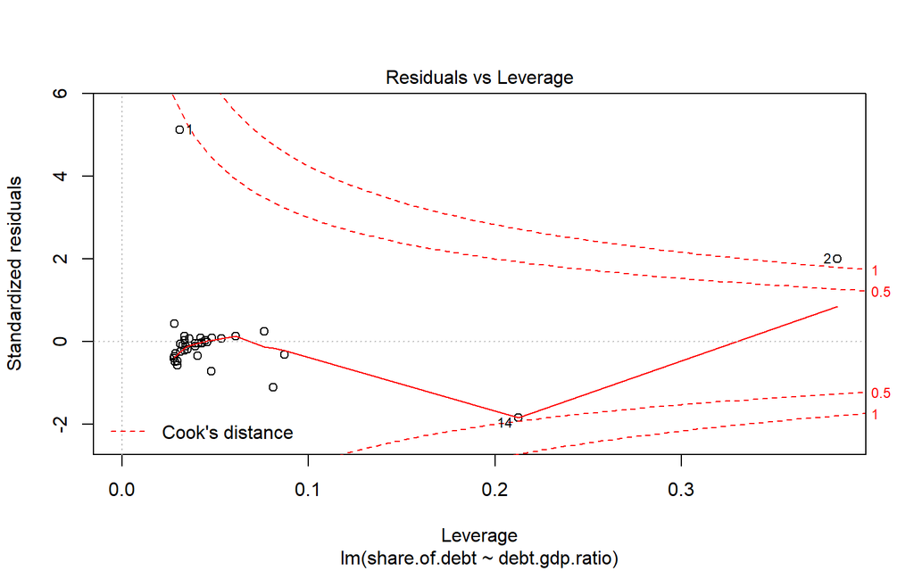

```r
plot(regresion_mco)
```

- Para el modelo original (raw data), puede verse en “Residuals Vs Fitted” una cierta **sospecha de heterocedasticidad** que habrá que confirmar posteriormente con un test, ya que parece que los residuos marcados con el 1, 2 y 14 son bastante desviados cuando los fitted values han aumentado.
- Para el “Q-Q Plot”, también surge la **sospecha de que existe una falta de normalidad en los datos**, con un sesgo muy fuerte por la derecha, que también tendremos que confirmar mediante un test.
- En el “Residuals Vs Leverage”, vemos que el valor 2 tiene una distancia de Cook mayor que uno, por lo que, siguiendo la teoría, **el valor 2 tiene influencia como valor atípico**. Vemos también que los valores marcados con 1 y 14 tienen una distancia de Cook de cerca del 0,5, por lo que existe una **alta posibilidad de que sean valores atípicos con influencia en el modelo**.

**Modelo con Logaritmos**

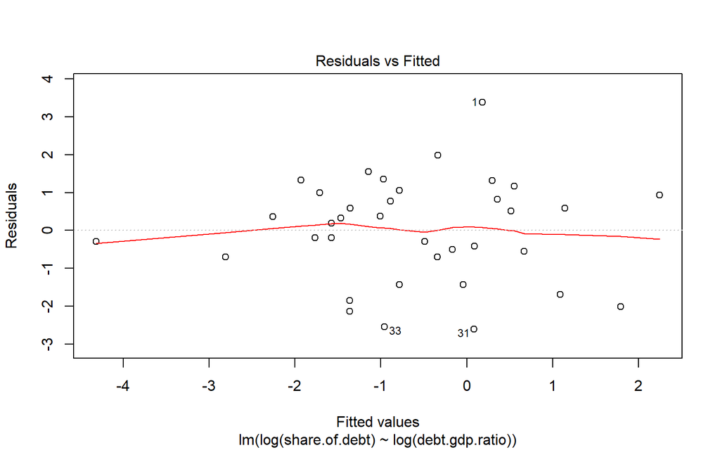

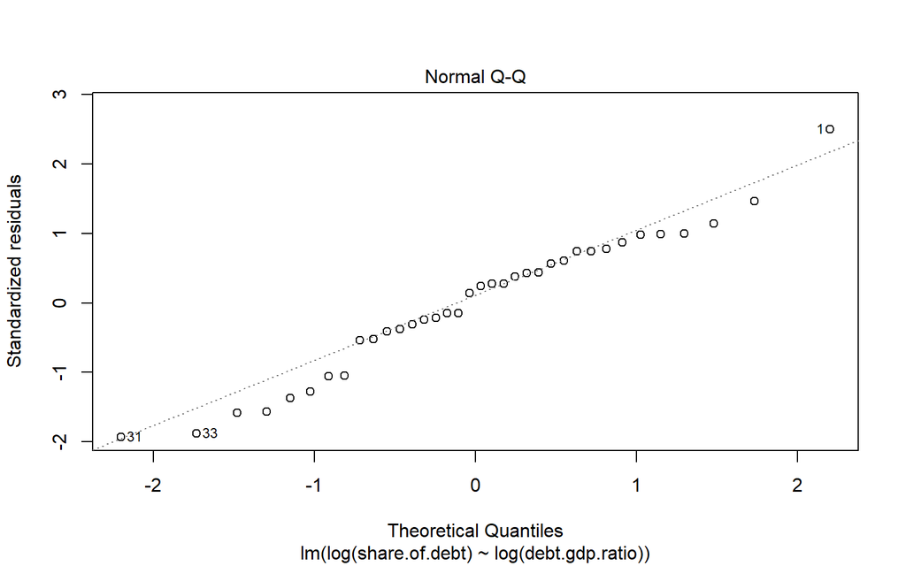

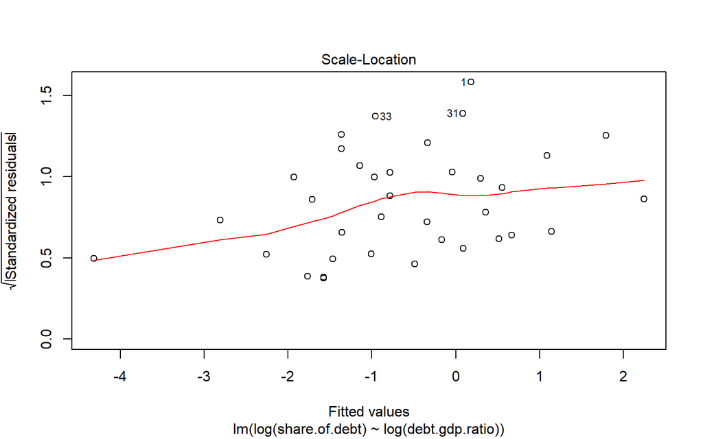

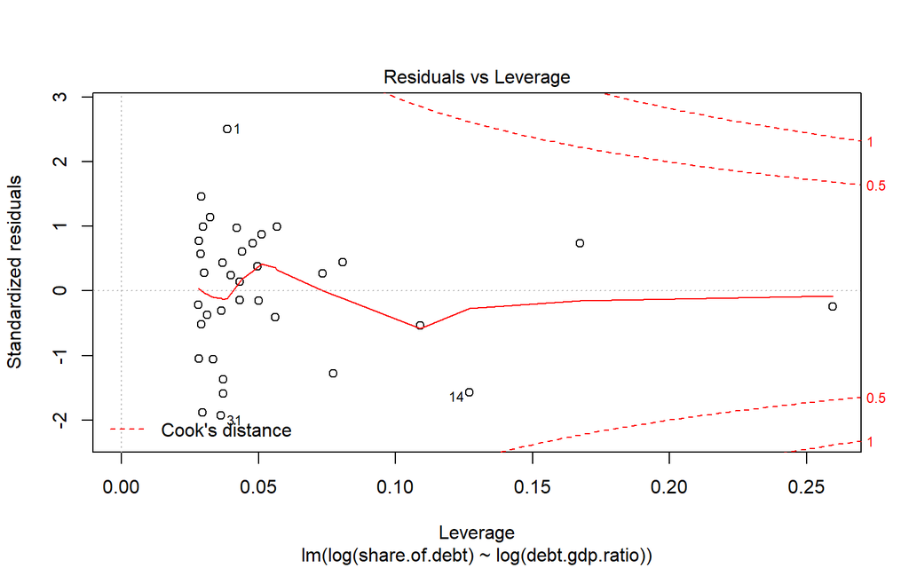

```r
plot(regresion_mco_log)
```

- En este caso, en el “Residuals Vs Fitted” **puede observarse una homocedasticidad probable**, puesto que parece que los residuos, aunque varían un poco, siguen la línea central y no se disparan.
- Respecto al “Q-Q Plot”, vemos como los valores se desvían de la diagonal varias veces pero al final vuelven, lo cual indica un **comportamiento que parece normal pero que tendremos que estudiar sin duda mediante el test de Saphiro.**
- Si nos fijamos en el “Residuals Vs Leverage”, podemos observar como, aunque existen valores con una distancia de Cook más elevada, ninguno llega al 0,5, por lo que es **es muy probable que no afecten estos valores en las estimaciones.**

### Estudios de normalidad y heterocedasticidad

#### Estudio de normalidad

Hagamos ahora los estudios de normalidad de ambos modelos:

Como tenemos sólo 36 variables, el estudio de normalidad de los residuos indicado para este caso es el de Shapiro-Wilks. En caso de haber tenido más de 50, hubiéramos usado Lilliefors.

**Modelo original**

```r
shapiro_mco_original <- shapiro.test(regresion_mco$residuals)
print(shapiro_mco_original)
```

```
##
##  Shapiro-Wilk normality test
##
## data:  regresion_mco$residuals
## W = 0.6, p-value = 3e-09
```

- Como se puede observar, el resultado del test de Shapiro para el modelo original sin logaritmos es con un p-valor por debajo de 0,05, por lo que se puede afirmar que **no existe normalidad en sus residuos**, tal y como ya sospechábamos en el apartado de las gráficas.

**Modelo con Logaritmos**

```r
shapiro_mco_logs <- shapiro.test(regresion_mco_log$residuals)
print(shapiro_mco_logs)
```

```
##
##  Shapiro-Wilk normality test
##
## data:  regresion_mco_log$residuals
## W = 1, p-value = 0.5
```

- Como se puede observar también aquí, el resultado del test de Shapiro muestra un p-valor superior a 0,05, lo que indica **normalidad en sus residuos**.

#### Estudio de heterocedasticidad

**Modelo original**

```r
library(lmtest)
bptest(regresion_mco, ~ debt.gdp.ratio, data = oecd)
```

```
##
##  studentized Breusch-Pagan test
##
## data:  regresion_mco
## BP = 1, df = 1, p-value = 0.3
```

- Como es observable en este test de heterocedasticidad, el p-valor es superior a 0,05, por lo que **nos quedamos con la hipótesis nula de homocedasticidad**. De este modo, rechazamos la alternativa de heterocedasticidad.

**Modelo con Logaritmos**

```r
bptest(regresion_mco_log, ~ debt.gdp.ratio, data = oecd)
```

```
##
##  studentized Breusch-Pagan test
##
## data:  regresion_mco_log
## BP = 0.6, df = 1, p-value = 0.4
```

- En este caso, el resultado vuelve a ser con un p-valor superior a 0,05, por lo que volvemos a **abrazar la hipótesis nula de homocedasticidad**, y rechazamos la hipótesis alternativa de heterocedasticidad.

### Conclusiones finales

Como se puede observar, en este ejercicio se han hecho dos modelos distintos comparando las bonanzas y deficiencias de cada uno.

En el **modelo original** se han obtenido los siguientes valores:

- **R^2**: 0,21
- **Variables explicativas**: Debt GDP Data
- **Normalidad de los residuos**: No existe normalidad
- **Heterocedasticidad de los residuos**: No existe heterocedasticidad

En el **modelo con logaritmos** se han obtenido los siguientes valores:

- **R^2**: 0,47
- **Variables explicativas**: Debt GDP Data, Intercept
- **Normalidad de los residuos**: Existe normalidad
- **Heterocedasticidad de los residuos**: No existe heterocedasticidad

**Habiendo estas conclusiones, sin ninguna duda el modelo con logaritmos resulta superior al modelo original**

## Ejercicio 3

- Plantee una regresión lineal múltiple que explique el porcentaje de deuda sobre el total de la deuda de la OCDE y el PIB utilizando una regresión polinómica de orden 2 y 3.
- Evalúe los resultados del modelo.
- Establezca un intervalo de confianza para los coeficientes con α=0.05 y α=0.10. Evalúe los resultados obtenidos en los dos modelos. Intente solucionar los problemas de los valores extremos utilizando variables dummies.

### Ejecución del modelo

```r
model_multiple_2 <- lm(share.of.debt ~ polym(gdp, degree = 2, raw = TRUE) , data = oecd)
summary(model_multiple_2)
```

```
##
## Call:
## lm(formula = share.of.debt ~ polym(gdp, degree = 2, raw = TRUE),
##     data = oecd)
##
## Residuals:
##    Min     1Q Median     3Q    Max
## -5.362 -0.847  0.237  0.762 10.180
##
## Coefficients:
##                                      Estimate Std. Error t value Pr(>|t|)
## (Intercept)                         -9.70e-01   5.07e-01   -1.91   0.0645 .
## polym(gdp, degree = 2, raw = TRUE)1  3.41e-03   4.32e-04    7.90  4.2e-09 ***
## polym(gdp, degree = 2, raw = TRUE)2 -7.90e-08   2.25e-08   -3.50   0.0013 **
## ---
## Signif. codes:  0 '***' 0.001 '**' 0.01 '*' 0.05 '.' 0.1 ' ' 1
##
## Residual standard error: 2.27 on 33 degrees of freedom
## Multiple R-squared:  0.899,  Adjusted R-squared:  0.893
## F-statistic:  147 on 2 and 33 DF,  p-value: <2e-16
```

- Es observable que **los grados uno y dos, para un 95% de confianza son significativos** (aportan valor a la predicción). El intercept no lo es para el 95%.
- El **R^2 es de 0,899**, el cual es muy alto y nos indica un buen ajuste.
- El **p-value es inferior a 0.05**, lo que indica que el modelo es significativo.

```r
model_multiple_3 <- lm(share.of.debt ~ polym(gdp, degree = 3, raw = TRUE) , data = oecd)
summary(model_multiple_3)
```

```
##
## Call:
## lm(formula = share.of.debt ~ polym(gdp, degree = 3, raw = TRUE),
##     data = oecd)
##
## Residuals:
##    Min     1Q Median     3Q    Max
## -6.682 -0.363 -0.007  0.237  3.687
##
## Coefficients:
##                                      Estimate Std. Error t value Pr(>|t|)
## (Intercept)                          5.50e-01   4.07e-01    1.35     0.19
## polym(gdp, degree = 3, raw = TRUE)1 -1.13e-03   7.48e-04   -1.51     0.14
## polym(gdp, degree = 3, raw = TRUE)2  1.37e-06   2.20e-07    6.21  5.9e-07 ***
## polym(gdp, degree = 3, raw = TRUE)3 -6.26e-11   9.50e-12   -6.58  2.0e-07 ***
## ---
## Signif. codes:  0 '***' 0.001 '**' 0.01 '*' 0.05 '.' 0.1 ' ' 1
##
## Residual standard error: 1.5 on 32 degrees of freedom
## Multiple R-squared:  0.957,  Adjusted R-squared:  0.953
## F-statistic:  238 on 3 and 32 DF,  p-value: <2e-16
```

- Es observable que **los grados dos y tres, para un 95% de confianza son significativos** (aportan valor a la predicción). El intercept no lo es.
- El **R^2 es de 0,957**, el cual es muy alto y nos indica un muy buen ajuste.
- Además, **el error residual estándar es más pequeño en este modelo**, por lo que tenemos un mejor ajuste.

### Obtención e interpretación de gráficas

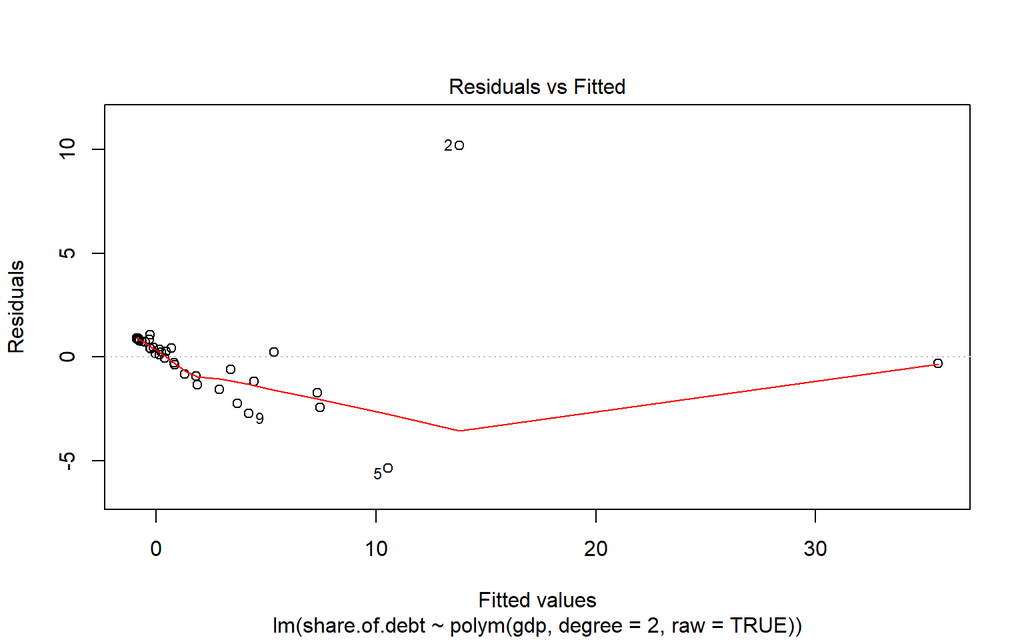

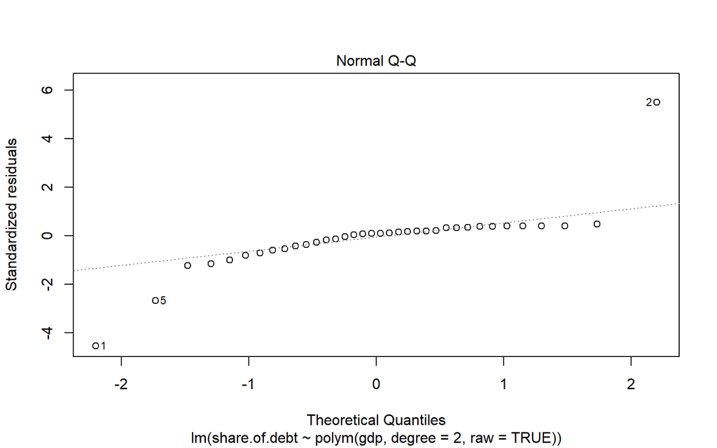

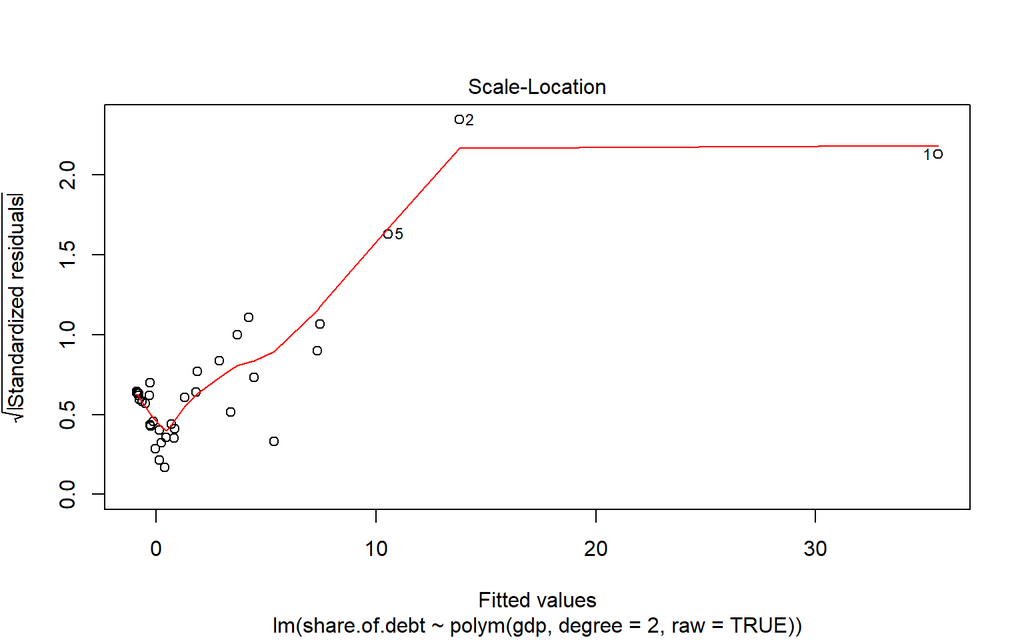

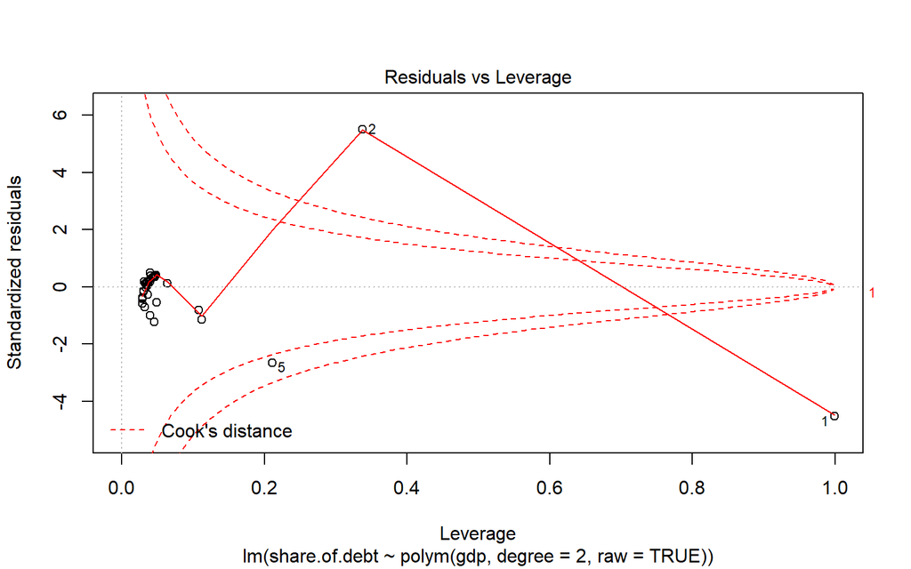

```r
plot(model_multiple_2)
```

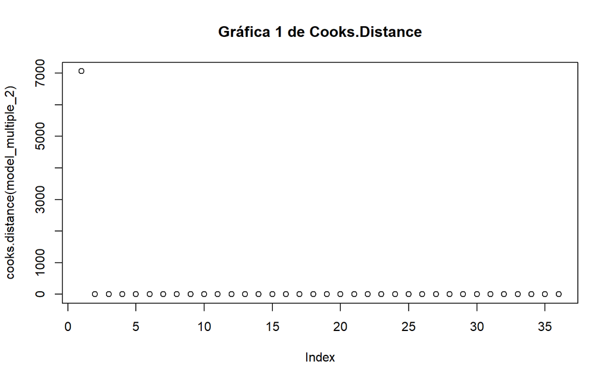

```r
plot(cooks.distance(model_multiple_2),
     main="Gráfica 1 de Cooks.Distance")
```

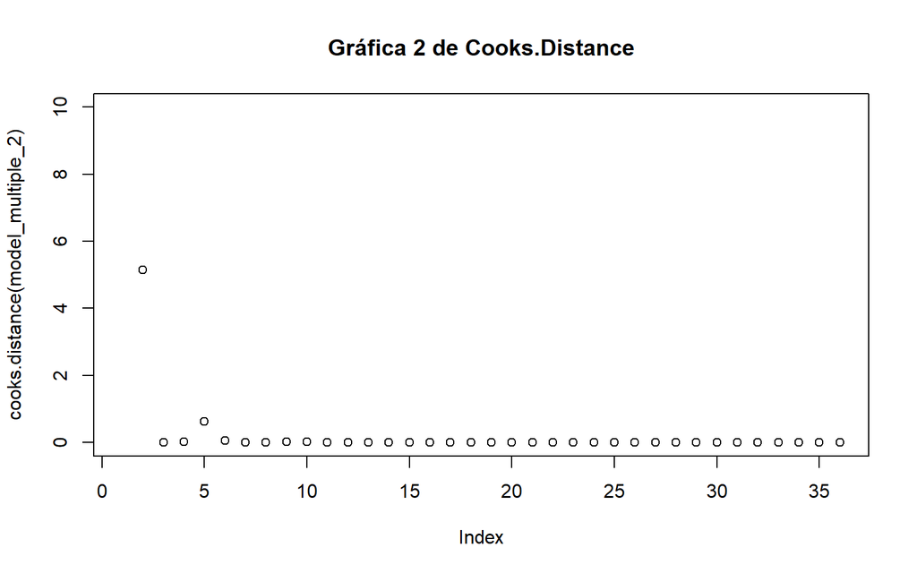

```r
plot(cooks.distance(model_multiple_2),
     ylim=c(0,10),
     main="Gráfica 2 de Cooks.Distance")
```

- En el “Residuals Vs Leverage”, se puede observar como los valores 1 y 2 **tienen influencia en las estimaciones siendo outliers** ya que tienen una distancia de Cook mayor de 1. Existen también valores con una distancia de Cook elevada, como es el 5.
- **Atendiendo a la *gráfica 1 de cooks.distance*, vemos que el valor 1 se dispara**. Si hacemos una amplicación (zoom) en la *gráfica 2 de cooks.distance*, vemos como el valor 1 no aparece (se sale del ylim), pero podemos ver que el valor 2 está en 5 aproximadamente, y el valor 5 también destaca respecto al resto.
- En el “Residuals Vs Fitted”, se puede observar como **puede haber una cierta heterocedasticidad que debe de ser analizada mediante un test**.
- En el Q-Q Plot, **se interpreta que no existe normalidad en la distribución**, pero igualmente será comprobado empíricamente con un test.

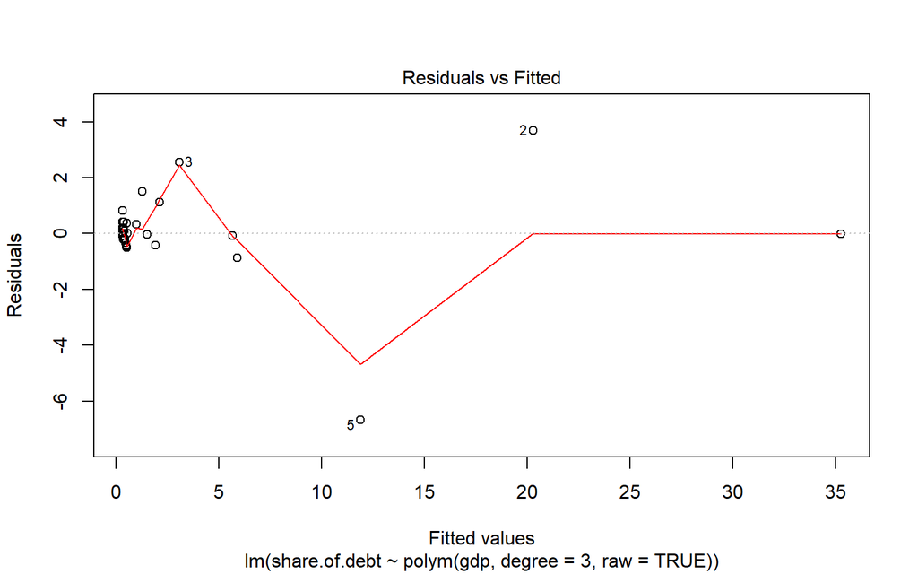

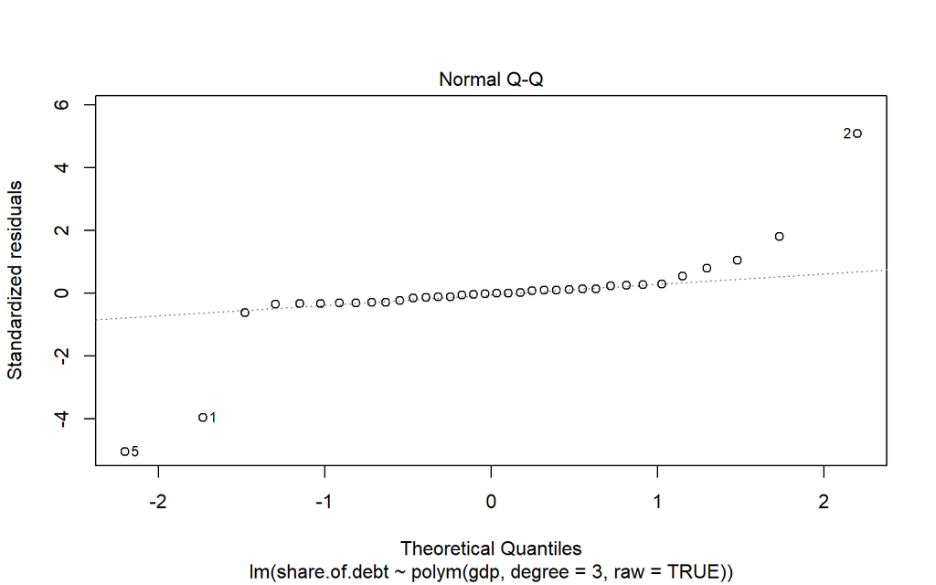

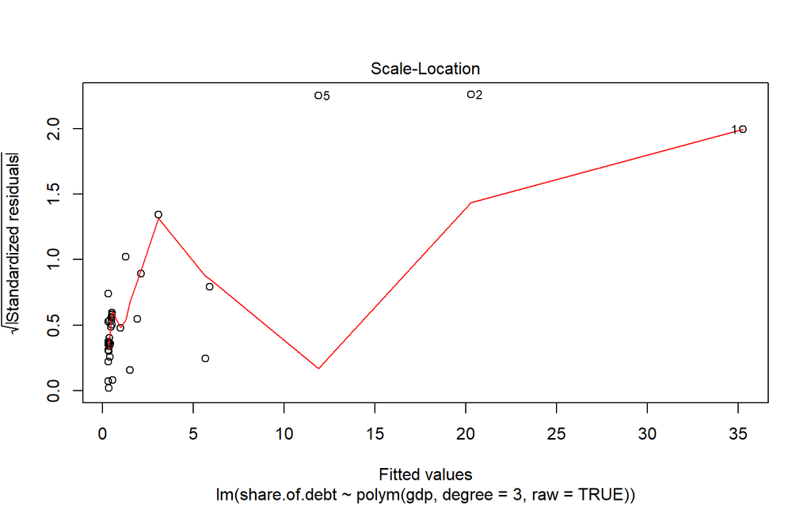

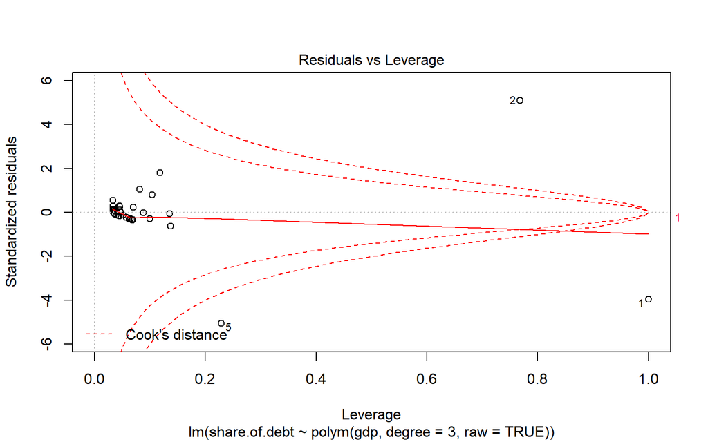

```r
plot(model_multiple_3)
```

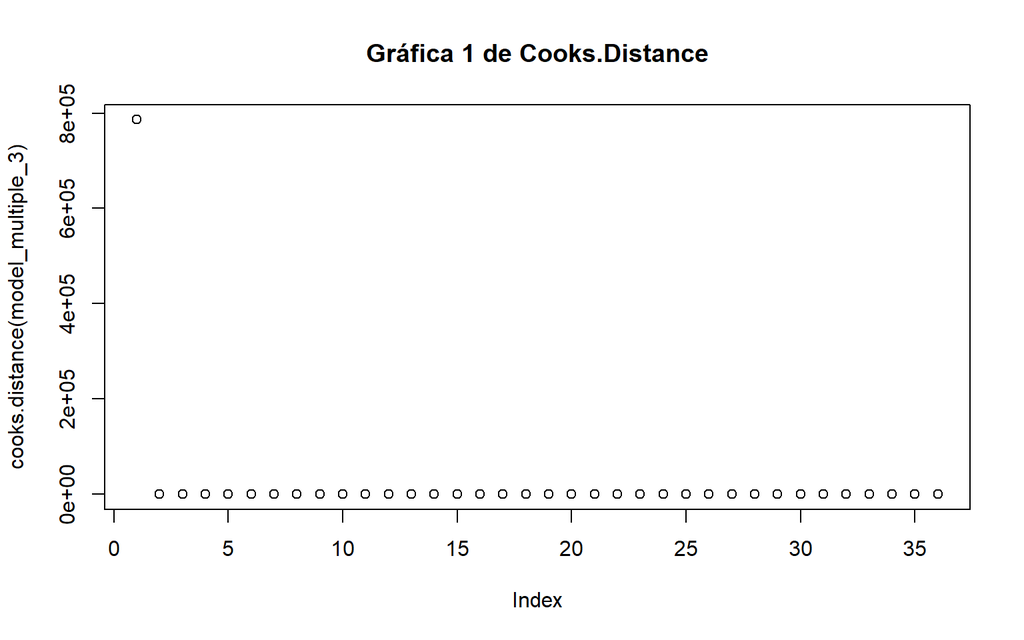

```r
plot(cooks.distance(model_multiple_3),
     main="Gráfica 1 de Cooks.Distance")
```

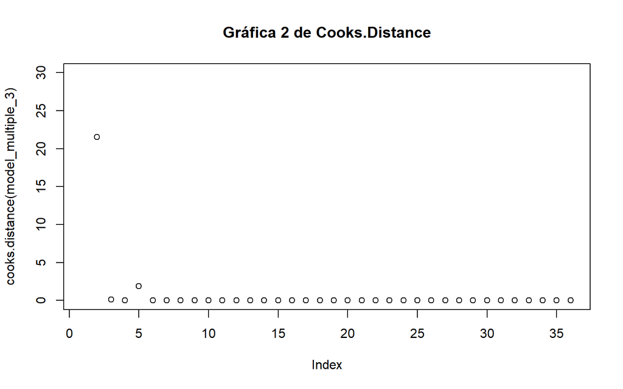

```r
plot(cooks.distance(model_multiple_3),
     ylim=c(0,30),
     main="Gráfica 2 de Cooks.Distance")
```

- En el “Residuals Vs Leverage”, se puede observar como **existen valores con influencia como outliers**: (1, 2, 5).
- Si nos fijamos en la *gráfica 1 de cooks.distance*, vemos como el valor 1 posee 800.000 de valor de cook, lo que indica con toda probabilidad que es un outlier y que influye. Si nos fijamos en la *gráfica 2 de cooks.distance*, podemos ver como el valor 2 también destaca, así como el valor 5.
- En el “Residuals Vs Fitted”, se puede observar como **puede haber una cierta heterocedasticidad que debe de ser analizada mediante un test**. Destaca el valor en fitted = 35, que vuelve no tener residuo.
- En el Q-Q Plot, **se interpreta que no existe normalidad en la distribución**, pero igualmente será comprobado empíricamente con un test.

### Comprobación de normalidad y heterocedasticidad

#### Estudio de normalidad

Como tenemos sólo 36 variables, el estudio de normalidad de los residuos indicado para este caso es el de Shapiro-Wilks. En caso de haber tenido más de 50, hubiéramos usado Lilliefors.

**Modelo Poly Coef. 2**

```r
shapiro_poly_2 <- shapiro.test(model_multiple_2$residuals)
print(shapiro_poly_2)
```

```
##
##  Shapiro-Wilk normality test
##
## data:  model_multiple_2$residuals
## W = 0.7, p-value = 2e-07
```

- Como se puede observar, el resultado del test de Shapiro para el modelo con coeficiente 2 es con un p-valor por debajo de 0,05, por lo que se puede afirmar que **no existe normalidad en sus residuos**, tal y como ya sospechábamos en el apartado de las gráficas.

**Modelo Poly Coef. 3**

```r
shapiro_poly_3 <- shapiro.test(model_multiple_3$residuals)
print(shapiro_poly_3)
```

```
##
##  Shapiro-Wilk normality test
##
## data:  model_multiple_3$residuals
## W = 0.6, p-value = 4e-08
```

- Como se puede observar también aquí, el resultado del test de Shapiro muestra un p-valor también inferior a 0,05, lo que vuelve a indicar que **no existe normalidad en sus residuos**, como se sospechaba.

#### Estudio de heterocedasticidad

Para el estudio de heterocedasticidad, usaremos el Test de White, que se recoge en R con la función “bptest”, de la librería “lmtest”

**Modelo Poly Coef. 2**

```r
library(lmtest)

bptest(model_multiple_2, ~ I(polym(gdp, degree=2, raw=TRUE)), data = oecd)
```

```
##
##  studentized Breusch-Pagan test
##
## data:  model_multiple_2
## BP = 18, df = 2, p-value = 1e-04
```

- El valor es inferior a 0,05, por lo que **acogemos la hipótesis alternativa de heterocedasticidad**.

**Modelo Poly Coef. 3**

```r
library(lmtest)

bptest(model_multiple_3, ~ I(polym(gdp, degree=3, raw=TRUE)), data = oecd)
```

```
##
##  studentized Breusch-Pagan test
##
## data:  model_multiple_3
## BP = 17, df = 3, p-value = 9e-04
```

- El p-valor obtenido es inferior a 0,05, por lo que también en este polinomio **acogemos la hipótesis alternativa de heterocedasticidad**.

### Obtención de intervalos de confianza y comparación

#### Intervalos de confianza α=0.05

**Coeficiente 2**

```r
confint(model_multiple_2)
```

```
##                                         2.5 %    97.5 %
## (Intercept)                         -2.00e+00  6.17e-02
## polym(gdp, degree = 2, raw = TRUE)1  2.53e-03  4.29e-03
## polym(gdp, degree = 2, raw = TRUE)2 -1.25e-07 -3.31e-08
```

**Coeficiente 3**

```r
confint(model_multiple_3)
```

```
##                                         2.5 %    97.5 %
## (Intercept)                         -2.79e-01  1.38e+00
## polym(gdp, degree = 3, raw = TRUE)1 -2.65e-03  3.91e-04
## polym(gdp, degree = 3, raw = TRUE)2  9.19e-07  1.82e-06
## polym(gdp, degree = 3, raw = TRUE)3 -8.19e-11 -4.32e-11
```

```r
#Diferencia coef 3
dif_coef3_int_95 <- confint(model_multiple_3, level=0.95)[1, 2] - confint(model_multiple_3, level=0.95)[1, 1]
#Diferencia coef 2
dif_coef2_int_95 <- confint(model_multiple_2, level=0.95)[1, 2] - confint(model_multiple_2, level=0.95)[1, 1]

print(paste0('Por ejemplo, si analizamos los intervalos de confianza para el intercept, obtenemos que la diferencia entre el 2.5% y el 97.5% para el modelo de coeficiente 3 es de ', dif_coef3_int_95, ', mientras que para el de coeficiente 2 es de ', dif_coef2_int_95))
```

```
## [1] "Por ejemplo, si analizamos los intervalos de confianza para el intercept, obtenemos que la diferencia entre el 2.5% y el 97.5% para el modelo de coeficiente 3 es de 1.65905691050439, mientras que para el de coeficiente 2 es de 2.06241637042143"
```

#### Intervalos de confianza α=0.10

**Coeficiente 2**

```r
confint(model_multiple_2, level=0.90)
```

```
##                                           5 %      95 %
## (Intercept)                         -1.83e+00 -1.12e-01
## polym(gdp, degree = 2, raw = TRUE)1  2.68e-03  4.15e-03
## polym(gdp, degree = 2, raw = TRUE)2 -1.17e-07 -4.08e-08
```

**Coeficiente 3**

```r
confint(model_multiple_3, level=0.90)
```

```
##                                           5 %      95 %
## (Intercept)                         -1.40e-01  1.24e+00
## polym(gdp, degree = 3, raw = TRUE)1 -2.40e-03  1.34e-04
## polym(gdp, degree = 3, raw = TRUE)2  9.95e-07  1.74e-06
## polym(gdp, degree = 3, raw = TRUE)3 -7.86e-11 -4.65e-11
```

```r
#Diferencia coef 3
dif_coef3_int_90 <- confint(model_multiple_3, level=0.90)[1, 2] - confint(model_multiple_3, level=0.90)[1, 1]
#Diferencia coef 2
dif_coef2_int_90 <- confint(model_multiple_2, level=0.90)[1, 2] - confint(model_multiple_2, level=0.90)[1, 1]

print(paste0('Por ejemplo, si analizamos los intervalos de confianza para el intercept, obtenemos que la diferencia entre el 5% y el 95% para el modelo de coeficiente 3 es de ', dif_coef3_int_90, ', mientras que para el de coeficiente 2 es de ', dif_coef2_int_90))
```

```
## [1] "Por ejemplo, si analizamos los intervalos de confianza para el intercept, obtenemos que la diferencia entre el 5% y el 95% para el modelo de coeficiente 3 es de 1.37965134826547, mientras que para el de coeficiente 2 es de 1.71556911386781"
```

### Solución de valores extremos mediante Dummies

#### Dummyficación y lanzamiento de modelos

La solución a este ejercicio la planteo dummificando los países outliers como sí, y los normales como no. En este momento, añado dicha variable al modelo para que “pueda aprender” sobre los outliers y probablemente mejore el modelo con esta solución.

```r
oecd['outlier_poly_2'] <- ifelse(cooks.distance(model_multiple_2) > 1, "Sí", "No")
oecd['outlier_poly_3'] <- ifelse(cooks.distance(model_multiple_3) > 1, "Sí", "No")
```

Ahora creo un modelo incluyendo esta variable:

```r
model_multiple_2_outs <- lm(share.of.debt ~ polym(gdp, degree=2, raw=TRUE) + outlier_poly_2, data = oecd)
summary(model_multiple_2_outs)
```

```
##
## Call:
## lm(formula = share.of.debt ~ polym(gdp, degree = 2, raw = TRUE) +
##     outlier_poly_2, data = oecd)
##
## Residuals:
##     Min      1Q  Median      3Q     Max
## -1.2392 -0.2638  0.0577  0.1705  2.2252
##
## Coefficients:
##                                      Estimate Std. Error t value Pr(>|t|)
## (Intercept)                         -1.87e-01   1.51e-01   -1.24     0.22
## polym(gdp, degree = 2, raw = TRUE)1  1.93e-03   1.46e-04   13.24  1.6e-14 ***
## polym(gdp, degree = 2, raw = TRUE)2 -4.76e-08   6.66e-09   -7.14  4.2e-08 ***
## outlier_poly_2Sí                     1.59e+01   8.25e-01   19.25  < 2e-16 ***
## ---
## Signif. codes:  0 '***' 0.001 '**' 0.01 '*' 0.05 '.' 0.1 ' ' 1
##
## Residual standard error: 0.65 on 32 degrees of freedom
## Multiple R-squared:  0.992,  Adjusted R-squared:  0.991
## F-statistic: 1.32e+03 on 3 and 32 DF,  p-value: <2e-16
```

```r
model_multiple_3_outs <- lm(share.of.debt ~ polym(gdp, degree=3, raw=TRUE) + outlier_poly_3, data = oecd)
summary(model_multiple_3_outs)
```

```
##
## Call:
## lm(formula = share.of.debt ~ polym(gdp, degree = 3, raw = TRUE) +
##     outlier_poly_3, data = oecd)
##
## Residuals:
##     Min      1Q  Median      3Q     Max
## -3.0555 -0.5580  0.0971  0.4899  2.4436
##
## Coefficients:
##                                      Estimate Std. Error t value Pr(>|t|)
## (Intercept)                          8.85e-01   3.22e-01    2.75    1e-02 **
## polym(gdp, degree = 3, raw = TRUE)1 -2.89e-03   6.86e-04   -4.22    2e-04 ***
## polym(gdp, degree = 3, raw = TRUE)2  2.43e-06   2.81e-07    8.66  9.0e-10 ***
## polym(gdp, degree = 3, raw = TRUE)3 -1.11e-10   1.26e-11   -8.84  5.7e-10 ***
## outlier_poly_3Sí                    -1.01e+01   2.13e+00   -4.76  4.3e-05 ***
## ---
## Signif. codes:  0 '***' 0.001 '**' 0.01 '*' 0.05 '.' 0.1 ' ' 1
##
## Residual standard error: 1.16 on 31 degrees of freedom
## Multiple R-squared:  0.975,  Adjusted R-squared:  0.972
## F-statistic:  305 on 4 and 31 DF,  p-value: <2e-16
```

#### Interpretación de gráficas

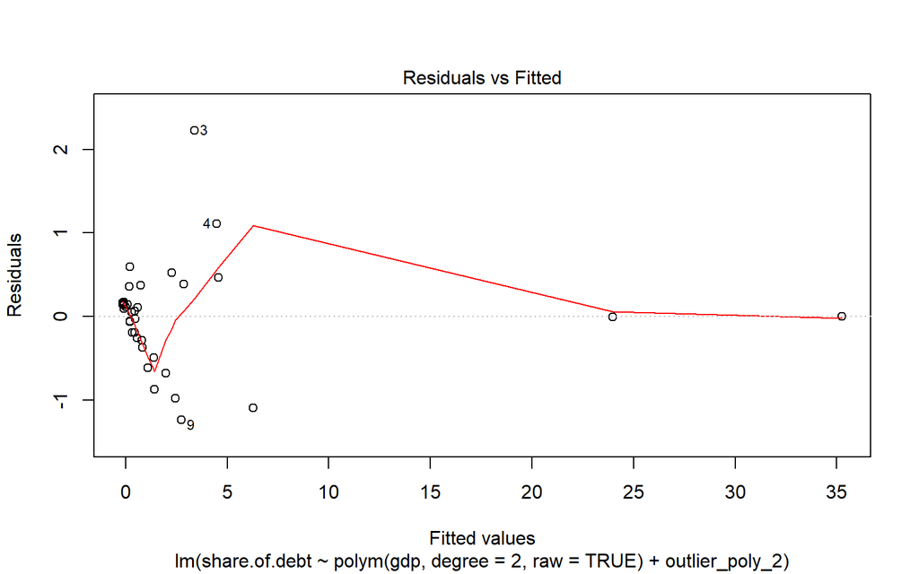

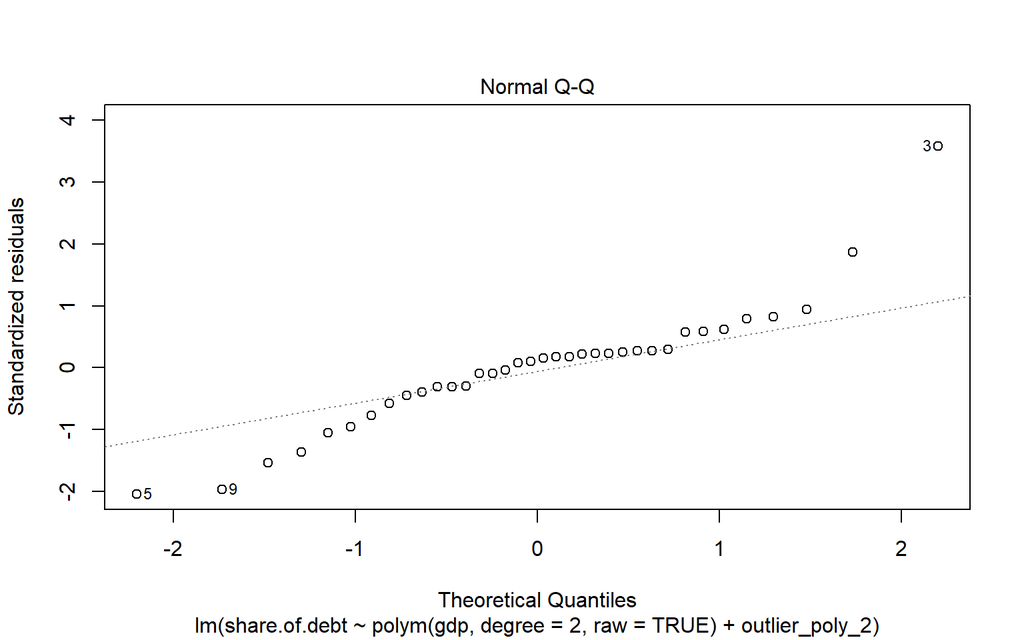

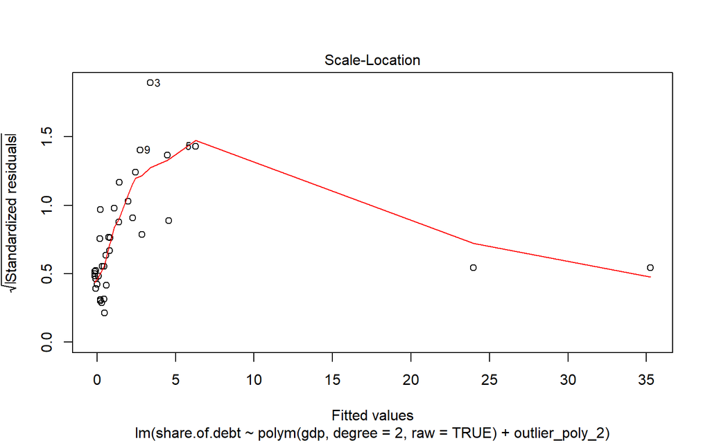

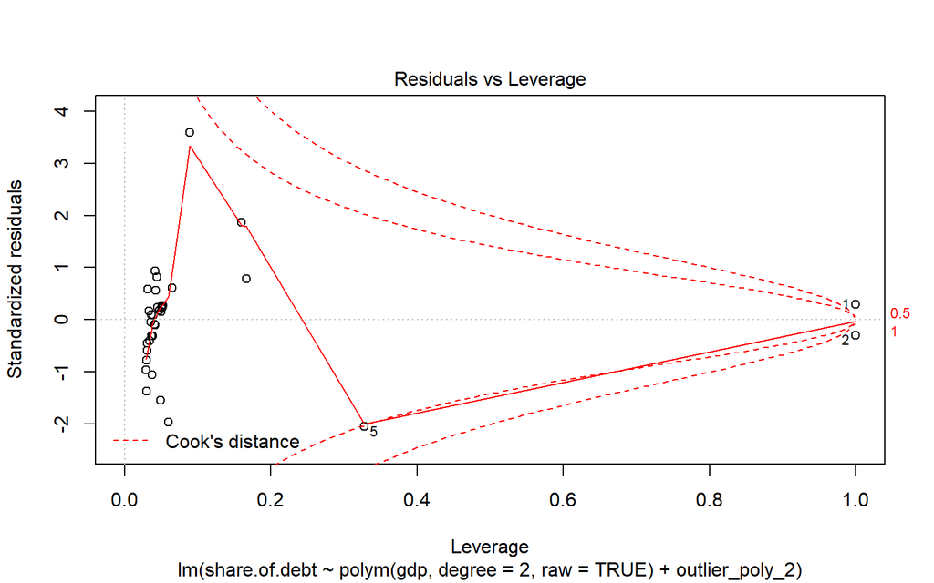

```r
plot(model_multiple_2_outs)
```

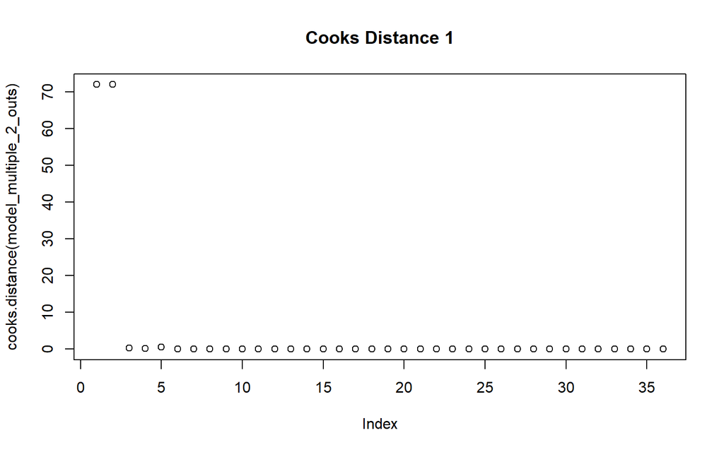

```r
plot(cooks.distance(model_multiple_2_outs), main="Cooks Distance 1")
```

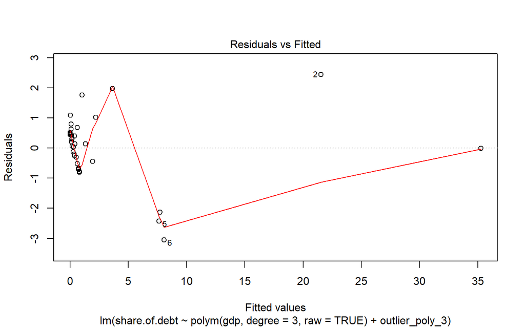

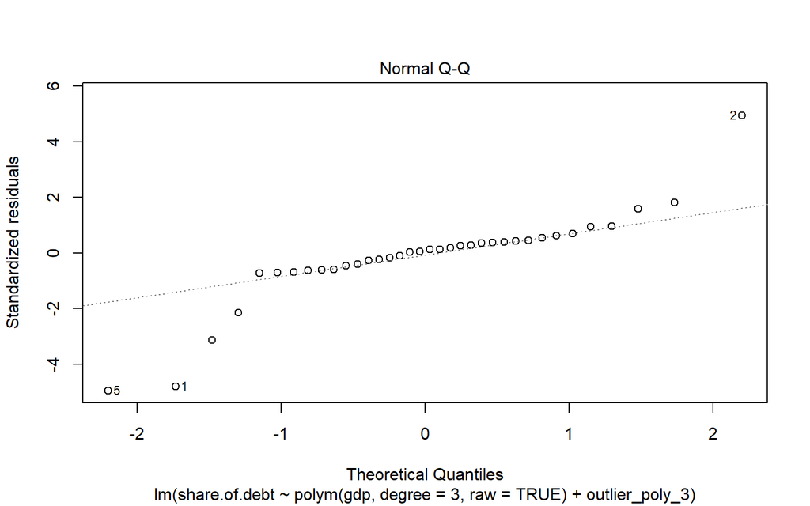

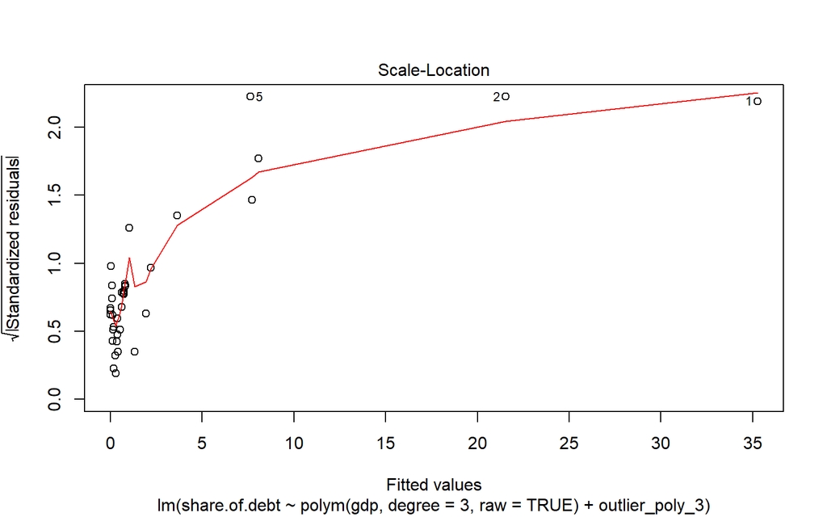

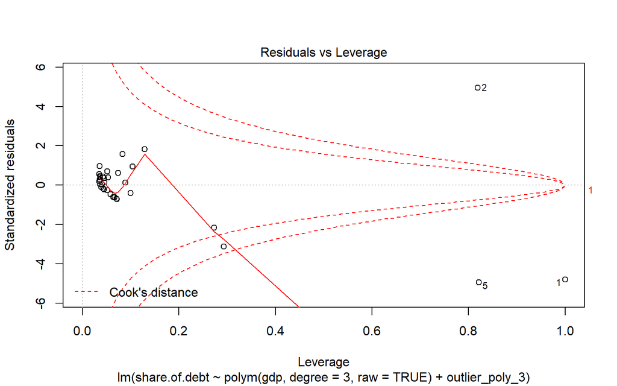

```r
plot(model_multiple_3_outs)
```

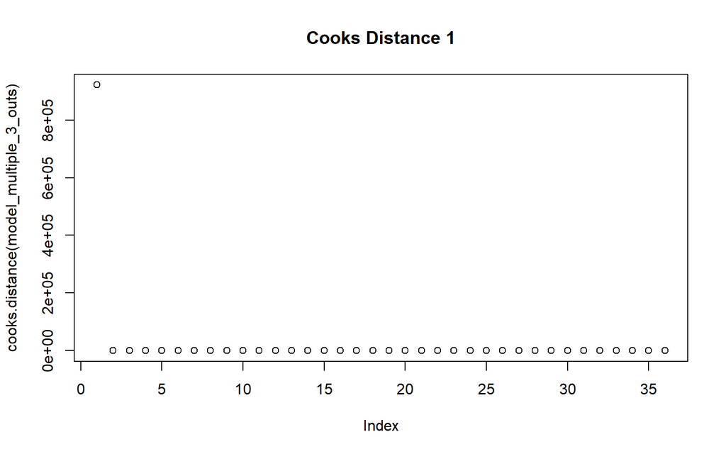

```r
plot(cooks.distance(model_multiple_3_outs), main="Cooks Distance 1")
```

- En el “Residuals Vs Fitted”, podemos comprobar como **podría haber heterocedasticidad en los residuos**, pero como existe cierta variación en los residuos es algo que debe de demostrarse mediante un test.
- En el “Q-Q Plot”, podemos observar **una falta de normalidad en los residuos**.
- En el “Residuals Vs Leverage”, podemos ver como **sigue habiendo valores outliers**, lo cual, al igual que en el apartado anterior, tiene sentido ya que no los hemos eliminado.

#### Test de Normalidad y Heterocedasticidad

##### Test de Normalidad

**Poly 2**

```r
shapiro_poly_2_outliers <- shapiro.test(model_multiple_2_outs$residuals)
print(shapiro_poly_2_outliers)
```

```
##
##  Shapiro-Wilk normality test
##
## data:  model_multiple_2_outs$residuals
## W = 0.9, p-value = 0.004
```

**Poly 3**

```r
shapiro_poly_3_outliers <- shapiro.test(model_multiple_3_outs$residuals)
print(shapiro_poly_3_outliers)
```

```
##
##  Shapiro-Wilk normality test
##
## data:  model_multiple_3_outs$residuals
## W = 0.9, p-value = 0.06
```

##### Test de heterocedasticidad

Para el estudio de heterocedasticidad, usaremos el Test de White

**Modelo Poly Coef. 2**

```r
library(lmtest)

bptest(model_multiple_2_outs, ~ I(polym(gdp, degree=2, raw=TRUE)) + I(outlier_poly_2), data = oecd)
```

```
##
##  studentized Breusch-Pagan test
##
## data:  model_multiple_2_outs
## BP = 11, df = 3, p-value = 0.01
```

- El valor es inferior a 0,05, por lo que **acogemos la hipótesis alternativa de heterocedasticidad**.

**Modelo Poly Coef. 3**

```r
library(lmtest)

bptest(model_multiple_3_outs, ~ I(polym(gdp, degree=3, raw=TRUE)) + I(outlier_poly_3), data = oecd)
```

```
##
##  studentized Breusch-Pagan test
##
## data:  model_multiple_3_outs
## BP = 26, df = 4, p-value = 3e-05
```

- El valor es inferior a 0,05, por lo que **acogemos la hipótesis alternativa de heterocedasticidad**.

### Conclusiones finales

Tras la realización de este ejercicio tenemos 4 modelos:

**Modelo de coeficiente 2**

Para este modelo, tenemos los siguientes resultados:

- **R^2**: 0.899
- **Variables significativas para 95% confianza**: Polym(gdp, 1), Polym(gdp, 2)
- **Test de normalidad de residuos**: No existe normalidad en sus residuos
- **Test de heterocedasticidad**: Abrazamos la hipótesis alternativa de heterocedasticidad

**Modelo de coeficiente 3**

Para este modelo, tenemos los siguientes resultados:

- **R^2**: 0.957
- **Variables significativas para 95% confianza**: Polym(gdp, 2), Polym(gdp, 3)
- **Test de normalidad de residuos**: No existe normalidad en sus residuos
- **Test de heterocedasticidad**: Abrazamos la hipótesis alternativa de heterocedasticidad

**Modelo de coeficiente 2 con detección de outliers**

**Modelo de coeficiente 3 con detección de outliers**

## Ejercicio 4

- Entre los modelos analizados en el curso, ¿cuál cree que es el más adecuado para resolver los problemas que ha encontrado en la mejor relación lineal entre el porcentaje de deuda sobre el total de la deuda de la OCDE y la tasa de deuda sobre el PIB?. Realice el ejercicio con el modelo que considere el más idóneo.
- Evalúe la normalidad de los residuos.
- Presente un gráfico con los porcentajes de deuda observados, los porcentajes estimados, y las bandas de confianza para los valores estimados con una α=0.05 y realice la predicción que daría el modelo para un país que lograra una tasa de deuda sobre el PIB del 25%.

### Planteamiento del modelo

El ejercicio nos está pidiendo primero la identificación del mejor R^2 de los modelos del ejercicio 2 (porcentaje de deuda sobre el total de la deuda de la OCDE y la tasa de deuda sobre el PIB). De esta manera, y volviendo al apartado de conclusiones de ese ejercicio, podemos observar que el modelo con mejor R^2 es el modelo en el que los datos están logaritmizados, porque se obtiene un R^2 de 0.47 respecto al de 0,21 con los datos sin logaritmizar.

Este modelo es muy robusto. A continuación, vuelvo a visualizar sus conclusiones:

- **R^2**: 0,47
- **Variables explicativas**: Debt GDP Data, Intercept
- **Normalidad de los residuos**: Existe normalidad
- **Heterocedasticidad de los residuos**: No existe heterocedasticidad

De esta manera, el único problema que tiene este modelo es que es demasiado simple, y no es capaz de explicar bien la variable dependiente, ya que todas sus variables son explicativas y con ello no es suficiente.

Así, el uso de otros modelos más complejos puede mejorar este R^2.

### Regresión Robusta

Aunque el modelo del ejercicio 3 no tiene valores outliers según la distancia de Cook, **seguramente no suponga una gran diferencia**, pero veamos a ver si mejora en algo:

```r
library(MASS)

robust_huber_4 <- rlm( log(share.of.debt) ~ log(debt.gdp.ratio), oecd )
robust_huber_4
```

```
## Call:
## rlm(formula = log(share.of.debt) ~ log(debt.gdp.ratio), data = oecd)
## Converged in 5 iterations
##
## Coefficients:
##         (Intercept) log(debt.gdp.ratio)
##               -8.78                2.03
##
## Degrees of freedom: 36 total; 34 residual
## Scale estimate: 1.31
```

```r
summary(robust_huber_4)
```

```
##
## Call: rlm(formula = log(share.of.debt) ~ log(debt.gdp.ratio), data = oecd)
## Residuals:
##    Min     1Q Median     3Q    Max
## -2.619 -0.726  0.229  0.958  3.375
##
## Coefficients:
##                     Value Std. Error t value
## (Intercept)         -8.78  1.59      -5.53
## log(debt.gdp.ratio)  2.03  0.39       5.21
##
## Residual standard error: 1.31 on 34 degrees of freedom
```

```r
robust_bisquare_4 <- rlm( log(share.of.debt) ~ log(debt.gdp.ratio), oecd, psi = psi.bisquare )
robust_bisquare_4
```

```
## Call:
## rlm(formula = log(share.of.debt) ~ log(debt.gdp.ratio), data = oecd,
##     psi = psi.bisquare)
## Converged in 5 iterations
##
## Coefficients:
##         (Intercept) log(debt.gdp.ratio)
##               -8.85                2.05
##
## Degrees of freedom: 36 total; 34 residual
## Scale estimate: 1.29
```

```r
summary(robust_bisquare_4)
```

```
##
## Call: rlm(formula = log(share.of.debt) ~ log(debt.gdp.ratio), data = oecd,
##     psi = psi.bisquare)
## Residuals:
##    Min     1Q Median     3Q    Max
## -2.627 -0.724  0.235  0.940  3.367
##
## Coefficients:
##                     Value  Std. Error t value
## (Intercept)         -8.851  1.583     -5.593
## log(debt.gdp.ratio)  2.051  0.389      5.274
##
## Residual standard error: 1.29 on 34 degrees of freedom
```

#### Estudio de normalidad

```r
shapiro_huber <- shapiro.test(robust_huber_4$residuals)
print(shapiro_huber)
```

```
##
##  Shapiro-Wilk normality test
##
## data:  robust_huber_4$residuals
## W = 1, p-value = 0.5
```

```r
shapiro_bisquare <- shapiro.test(robust_bisquare_4$residuals)
print(shapiro_bisquare)
```

```
##
##  Shapiro-Wilk normality test
##
## data:  robust_bisquare_4$residuals
## W = 1, p-value = 0.5
```

- Como es lógico, ante modelos tan similares, **sigue existiendo normalidad en sus residuos**

#### Estudio de la heterocedasticidad

```r
bptest(robust_huber_4, ~ debt.gdp.ratio, data = oecd)
```

```
##
##  studentized Breusch-Pagan test
##
## data:  robust_huber_4
## BP = 0.6, df = 1, p-value = 0.4
```

```r
bptest(robust_bisquare_4, ~ debt.gdp.ratio, data = oecd)
```

```
##
##  studentized Breusch-Pagan test
##
## data:  robust_bisquare_4
## BP = 0.6, df = 1, p-value = 0.4
```

- También, como es lógico, el estudio de la heterocedasticidad es el mismo, por lo que **sigue existiendo homocedasticidad**

#### Estudio del AIC

```r
AIC(robust_huber_4)
```

```
## [1] 129
```

```r
AIC(robust_bisquare_4)
```

```
## [1] 129
```

Comparando los modelos, se ve que son iguales. **No tendríamos capacidad de decidirnos por uno siguiendo el AIC.**

#### Conclusiones

La regresión robusta, como se preveía, no mejora significativamente los resultados obtenidos con la regresión lineal en la que se aplicaron logaritmos. Esto tiene sentido ya que, al tomar logaritmos en su momento, suavizamos los outliers quedándonos sin ellos, por lo que **la regresión robusta**, aunque el intento siempre es interesante, **no aporta en este modelo**.

### Regresión Lineal Múltiple

Como el nuestro problema la regresión lineal simple es simple en sí, el uso de una regresión lineal múltiple puede ser una buena opción para complicar el modelo y poder obtener mejores resultados.

```r
reg_mult <- lm(log(share.of.debt) ~ log(debt.gdp.ratio) + log(gdp), data = oecd)
reg_mult
```

```
##
## Call:
## lm(formula = log(share.of.debt) ~ log(debt.gdp.ratio) + log(gdp),
##     data = oecd)
##
## Coefficients:
##         (Intercept)  log(debt.gdp.ratio)             log(gdp)
##             -10.289                0.926                0.982
```

```r
summary(reg_mult)
```

```
##
## Call:
## lm(formula = log(share.of.debt) ~ log(debt.gdp.ratio) + log(gdp),
##     data = oecd)
##
## Residuals:
##     Min      1Q  Median      3Q     Max
## -0.1160 -0.0481 -0.0143  0.0359  0.4244
##
## Coefficients:
##                     Estimate Std. Error t value Pr(>|t|)
## (Intercept)         -10.2892     0.1050   -98.0   <2e-16 ***
## log(debt.gdp.ratio)   0.9259     0.0288    32.1   <2e-16 ***
## log(gdp)              0.9815     0.0116    84.4   <2e-16 ***
## ---
## Signif. codes:  0 '***' 0.001 '**' 0.01 '*' 0.05 '.' 0.1 ' ' 1
##
## Residual standard error: 0.0948 on 33 degrees of freedom
## Multiple R-squared:  0.998,  Adjusted R-squared:  0.997
## F-statistic: 6.83e+03 on 2 and 33 DF,  p-value: <2e-16
```

Como se puede observar, este modelo a priori es muy bueno, con un 99.8 de R^2 y con todas las variables siendo significativas. Además, su p-value es muy cercano a 0.